# Notebook 09 – Solutions

## Getting Started

Before running this notebook, select “Session > Restart R and Clear Output” in the menu above to start a new R session. This will clear any old data sets and give us a blank slate to start with.

After starting a new session, run the following code chunk to load the libraries and data that we will be working with today.

I have set the options `include=FALSE` and `message=FALSE` to avoid cluttering the solutions with all the output from this code.

# Practice

## Largest City and Köppen Datasets

In this notebook we will work with the largest cities dataset:

```r
cities <- read_csv(file.path("data", "largest_cities.csv"))
```

We will also load a dataset containing metadata about the Köppen climate classification scores.

```r
koppen <- read_csv(file.path("data", "koppen_metadata.csv"))
koppen
```

```
## # A tibble: 31 × 3
##    code  name                                                     color
##    <chr> <chr>                                                    <chr>
##  1 Af    Tropical rainforest climate                              #0000FE
##  2 Am    Tropical monsoon climate                                 #0077FF
##  3 Aw    Tropical savanna climate with dry-winter characteristics #46A9FA
##  4 As    Tropical savanna climate with dry-summer characteristics #46A9FA
##  5 BWh   Hot desert climates                                      #FE0000
##  6 BWk   Cold desert climates                                     #FE9695
##  7 BSh   Hot semi-arid climates                                   #F5A301
##  8 BSk   Cold semi-arid climates                                  #FFDB63
##  9 Csa   Mediterranean hot summer climates                        #FFFF00
## 10 Csb   Mediterranean warm/cool summer climates                  #C6C700
## # … with 21 more rows
```

## Joining Climate Data

In the code block below, use the `left_join` function to combine the `cities` data set with the `koppen` metadata. Note that the key has a different name in each of the two data sets.

```r
cities %>%
  left_join(koppen, by = c("koppen_code" = "code"))
```

```
## # A tibble: 81 × 28
##    name.x      country city_definition population city_pop city_area metro_pop metro_area
##    <chr>       <chr>   <chr>                <dbl>    <dbl>     <dbl>     <dbl>      <dbl>
##  1 Tokyo       Japan   Metropolis pre…       37.4    13.5       2191      37.3      13452
##  2 Delhi       India   National capit…       28.5    16.8       1484      29         3483
##  3 Shanghai    China   Municipality          25.6    24.2       6341      NA           NA
##  4 São Paulo   Brazil  Municipality          21.6    12.3       1521      21.7       7947
##  5 Mexico City Mexico  City-state            21.6     8.92      1485      20.9       7854
##  6 Cairo       Egypt   Urban governor…       20.1     9.5       3085      NA           NA
##  7 Mumbai      India   Municipality          20.0    12.5        603      24.4       4355
##  8 Beijing     China   Municipality          19.6    21.7      16411      NA           NA
##  9 Dhaka       Bangla… Capital city          19.6    14.4        338      14.5         NA
## 10 Osaka       Japan   Designated city       19.3     2.72       225      19.3      13228
## # … with 71 more rows, and 20 more variables: urban_pop <dbl>, urban_area <dbl>,
## #   wiki <chr>, country_code2 <chr>, country_code3 <chr>,
## #   country_name_official <chr>, continent <chr>, lon <dbl>, lat <dbl>,
## #   koppen_code <chr>, koppen_main <chr>, city <chr>, num <dbl>,
## #   cost_of_living <dbl>, cost_rent <dbl>, cost_groceries <dbl>,
## #   cost_restaurant <dbl>, local_pp <dbl>, name.y <chr>, color <chr>
```

Take a close look at the data set you created in the last question. Scrolling all the way to the final columns, you should see the name of the climate region and the default color added into the data set.

Something, however, has happened to the first variable in the combined data set. What is the (new) name of the first variable in the combined output? **Answer**: name.x

It turns out that both the `cities` data set and the `koppen` dataset both contain a variable named “name”. In R, a data set cannot contain two columns with the same names. By default, `left_join` adds a suffix to distinguish variables that came from the first data set and those that came from the second dataset. I generally find the default suffix values to not be ideal because they change both the names in the left table (the one that contains the observations of interest) as well as the the new metadata columns. Let’s see how to change these suffix values.

The `left_join` function has an optional argument called `suffix`. You can supply two string values to it to describe what suffix values are placed on the first and second tables in the join. The default value is `c(".x", ".y")`. I typically find something with the first entry empty to be more practical. So, for example: `c("", "_koppen")`. In the code below, repeat the left join with this suffix option:

```r
cities %>%
  left_join(koppen, by = c("koppen_code" = "code"), suffix = c("", "_koppen"))
```

```
## # A tibble: 81 × 28
##    name        country city_definition population city_pop city_area metro_pop metro_area
##    <chr>       <chr>   <chr>                <dbl>    <dbl>     <dbl>     <dbl>      <dbl>
##  1 Tokyo       Japan   Metropolis pre…       37.4    13.5       2191      37.3      13452
##  2 Delhi       India   National capit…       28.5    16.8       1484      29         3483
##  3 Shanghai    China   Municipality          25.6    24.2       6341      NA           NA
##  4 São Paulo   Brazil  Municipality          21.6    12.3       1521      21.7       7947
##  5 Mexico City Mexico  City-state            21.6     8.92      1485      20.9       7854
##  6 Cairo       Egypt   Urban governor…       20.1     9.5       3085      NA           NA
##  7 Mumbai      India   Municipality          20.0    12.5        603      24.4       4355
##  8 Beijing     China   Municipality          19.6    21.7      16411      NA           NA
##  9 Dhaka       Bangla… Capital city          19.6    14.4        338      14.5         NA
## 10 Osaka       Japan   Designated city       19.3     2.72       225      19.3      13228
## # … with 71 more rows, and 20 more variables: urban_pop <dbl>, urban_area <dbl>,
## #   wiki <chr>, country_code2 <chr>, country_code3 <chr>,
## #   country_name_official <chr>, continent <chr>, lon <dbl>, lat <dbl>,
## #   koppen_code <chr>, koppen_main <chr>, city <chr>, num <dbl>,
## #   cost_of_living <dbl>, cost_rent <dbl>, cost_groceries <dbl>,
## #   cost_restaurant <dbl>, local_pp <dbl>, name_koppen <chr>, color <chr>
```

Verify that the variable names match what you expected to find in the new data set. The same suffix option can be used to modify the output for other table joins.

Below, pipe the joined data set from the last question into a scatterplot with longitude on the x-axis and latitude on the y-axis. Color the points based on the default Köppen codes using an identity color scale:

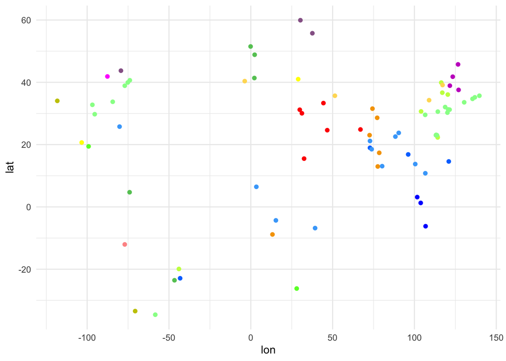

```r
cities %>%
  left_join(koppen, by = c("koppen_code" = "code"), suffix = c("", "_koppen")) %>%
  ggplot(aes(lon, lat)) +
    geom_point(aes(color = color)) +
    scale_color_identity()
```

### Manual colors with a legend

There is one problem with the plot that we created to color the cities by their Köppen codes. There’s no legend for the plot. A way to rectify this problem is to color the points using the variable `name_koppen` and use the colors in the `koppen` metadata table to describe a manual scale with `scale_color_manual`. Specifically, we need:

`scale_color_manual(values = koppen$color, labels = koppen$name)`.

Below, redo your plot with this color value and scale.

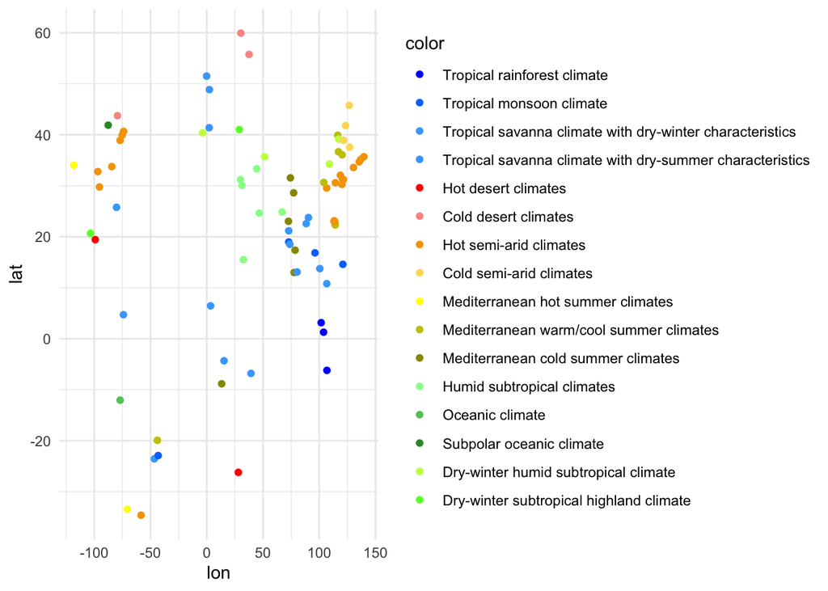

```r
cities %>%
  left_join(koppen, by = c("koppen_code" = "code"), suffix = c("", "_koppen")) %>%
  ggplot(aes(lon, lat)) +
    geom_point(aes(color = color)) +
    scale_color_manual(values = koppen$color, labels = koppen$name)
```

The plot should like nice, but does requires a wide screen to see all of the colors given the long descriptions in the legend.

## Creating join table

Sometimes it can be useful to create a small metadata table directly in R using the `tibble` function. This can than be used to more easily do mutating or filtering of a dataset. We will practice this by looking at the continents in the `cities` dataset. To start, compute the unique values of the continent variable in the dataset (there are many different ways to do this):

```r
cities %>%
  group_by(continent) %>%
  summarize()
```

```
## # A tibble: 5 × 1
##   continent
##   <chr>
## 1 Africa
## 2 Asia
## 3 Europe
## 4 North America
## 5 South America
```

Here are the continent names in French:

- Asie, Amérique du Sud, Amérique du Nord, Afrique, Europe)

In the next question, use the mutate function to create a new variable called `continent_fr` in the `cities` data that gives the continent names in French. Pipe this to a plot with longitude on the x-axis, latitude on the y-axis, and the points colored to the name of the continent in French:

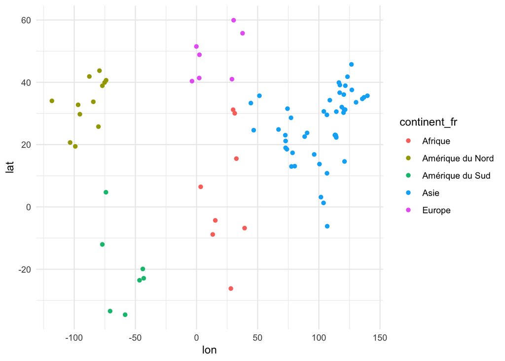

```r
cities %>%
  mutate(continent_fr = "default") %>%
  mutate(continent_fr = if_else(continent == "Asia", "Asie", continent_fr)) %>%
  mutate(continent_fr = if_else(continent == "South America", "Amérique du Sud", continent_fr)) %>%
  mutate(continent_fr = if_else(continent == "North America", "Amérique du Nord", continent_fr)) %>%
  mutate(continent_fr = if_else(continent == "Africa", "Afrique", continent_fr)) %>%
  mutate(continent_fr = if_else(continent == "Europe", "Europe", continent_fr)) %>%
  ggplot(aes(lon, lat)) +
    geom_point(aes(color = continent_fr))
```

Next, create a data set using the `tibble()` function and save the data set as a variable called `continent_names`. The data will contains one row for each continent and should have two variables: `continent` and `continent_fr`. This gives a mapping between the English and French names.

```r
continent_names <- tibble(
  continent = c("Asia", "South America", "North America", "Africa", "Europe"),
  continent_fr = c("Asie", "Amérique du Sud", "Amérique du Nord", "Afrique", "Europe")
)

continent_names
```

```
## # A tibble: 5 × 2
##   continent     continent_fr
##   <chr>         <chr>
## 1 Asia          Asie
## 2 South America Amérique du Sud
## 3 North America Amérique du Nord
## 4 Africa        Afrique
## 5 Europe        Europe
```

In the code below, join the `cities` dataset with the `continent_names` dataset. Pipe the data into a plot with longitude on the x-axis and latitude on the y-axis, coloring the points with the variable `continent_fr`.

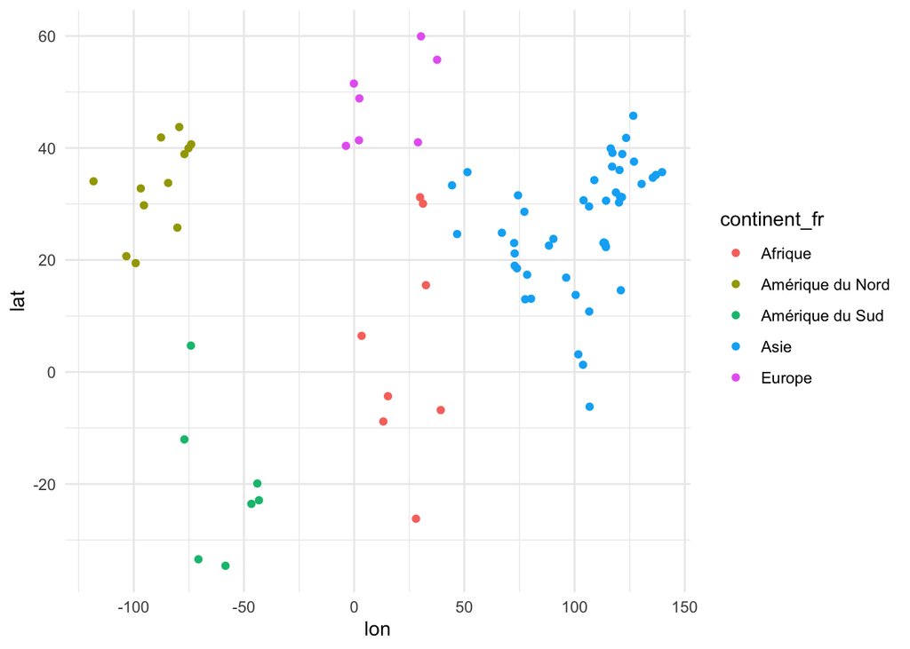

```r
cities %>%
  left_join(continent_names, by = "continent") %>%
  ggplot(aes(lon, lat)) +
    geom_point(aes(color = continent_fr))
```

The plot should now show the legend in French. In the code below, recreate the plot but add better labels for the x-axis, y-axis, and legend. Add a short title.

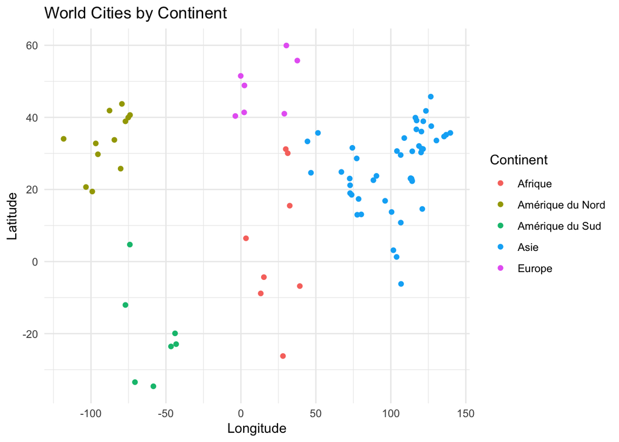

```r
cities %>%
  left_join(continent_names, by = "continent") %>%
  ggplot(aes(lon, lat)) +
    geom_point(aes(color = continent_fr)) +
    labs(x = "Longitude", y = "Latitude", color = "Continent",
         title = "World Cities by Continent")
```

## Semi_join: an example

We have learned about the verb `slice`. There is another variation called `slice_sample` that takes a random subset of the data. It takes a named argument called `n` that tells us how many rows to randomly select from the data. In the block below, randomly select five rows from the cities dataset (run the code a few times to verify that the results change):

```r
cities %>%
  slice_sample(n = 5)
```

```
## # A tibble: 5 × 26
##   name    country  city_definition population city_pop city_area metro_pop metro_area
##   <chr>   <chr>    <chr>                <dbl>    <dbl>     <dbl>     <dbl>      <dbl>
## 1 Dallas  United … City                  6.10     1.34       882      7.47      22463
## 2 Harbin  China    City (sub-prov…       6.12    10.6      53068     NA            NA
## 3 Madrid  Spain    Municipality          6.50     3.27       606      6.64         NA
## 4 Ho Chi… Vietnam  Municipality          8.14     7.43      2061     NA            NA
## 5 Guadal… Mexico   Municipality          5.02     1.46     10244      5.00       2734
## # … with 18 more variables: urban_pop <dbl>, urban_area <dbl>, wiki <chr>,
## #   country_code2 <chr>, country_code3 <chr>, country_name_official <chr>,
## #   continent <chr>, lon <dbl>, lat <dbl>, koppen_code <chr>, koppen_main <chr>,
## #   city <chr>, num <dbl>, cost_of_living <dbl>, cost_rent <dbl>,
## #   cost_groceries <dbl>, cost_restaurant <dbl>, local_pp <dbl>
```

The `slice_sample` function respects grouping by sampling randomly within each group. Test this below we randomly picking two cities from each continent:

```r
cities %>%
  group_by(continent) %>%
  slice_sample(n = 2)
```

```
## # A tibble: 10 × 26
## # Groups:   continent [5]
##    name   country  city_definition population city_pop city_area metro_pop metro_area
##    <chr>  <chr>    <chr>                <dbl>    <dbl>     <dbl>     <dbl>      <dbl>
##  1 Johan… South A… Metropolitan m…       5.49    NA           NA     NA            NA
##  2 Alexa… Egypt    Urban governor…       5.09    NA           NA     NA            NA
##  3 Kuala… Malaysia City                  7.56     1.77       243      7.2        2793
##  4 Dongg… China    Prefecture-lev…       7.36     8.34      2465     NA            NA
##  5 Saint… Russia   Federal city          5.38    NA           NA     NA            NA
##  6 Madrid Spain    Municipality          6.50     3.27       606      6.64         NA
##  7 Houst… United … City                  6.12     2.33      1553      7.00      21395
##  8 Los A… United … City                 12.5      3.99      1214     13.3       12559
##  9 Rio d… Brazil   Municipality         13.3      6.52      1221     12.6        5327
## 10 São P… Brazil   Municipality         21.6     12.3       1521     21.7        7947
## # … with 18 more variables: urban_pop <dbl>, urban_area <dbl>, wiki <chr>,
## #   country_code2 <chr>, country_code3 <chr>, country_name_official <chr>,
## #   continent <chr>, lon <dbl>, lat <dbl>, koppen_code <chr>, koppen_main <chr>,
## #   city <chr>, num <dbl>, cost_of_living <dbl>, cost_rent <dbl>,
## #   cost_groceries <dbl>, cost_restaurant <dbl>, local_pp <dbl>
```

We are going to do something slightly different that requires the use of a filtering join. We want to pick 5 randomly selected countries from the data set and then return all of the cities that are within those countries. The sampling should not be weighted by the number of cities within each countries that are in our data set.

To start, create a table called `selected_countries` that has a single column called `country` and five rows that have been selected from the countries in the cities data. Make sure that you are not over-weighting based on the number of cities (so China should be just as likely as Angola to be selected).

```r
selected_countries <- cities %>%
  group_by(country) %>%
  summarize() %>%
  slice_sample(n = 5)

selected_countries
```

```
## # A tibble: 5 × 1
##   country
##   <chr>
## 1 Malaysia
## 2 Brazil
## 3 Egypt
## 4 Sudan
## 5 United Kingdom
```

Now, use a semi-join to select all of the cities that are in these countries from the cities data set. Pipe the selected cities into a scatter plot with longitude on the x-axis, latitude on the y-axis, and the points colored by country.

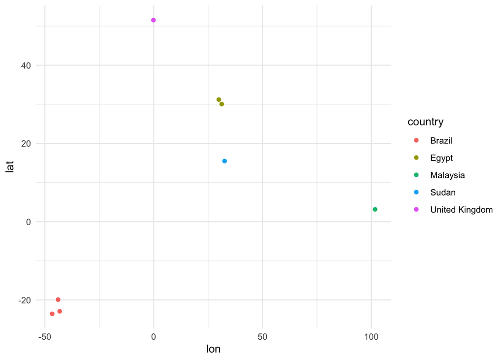

```r
cities %>%
  semi_join(selected_countries, by = "country") %>%
  ggplot(aes(lon, lat)) +
    geom_point(aes(color = country))
```

While a bit artificial, this is a good example of how and why you might use filtering joins.